# Big Data Analysis

ML Basics and CART

Christoph Kern

## Setup

```r
library(ggplot2)
library(ggmap)
library(GGally)
library(rpart)
library(partykit)
library(pdp)
library(caret)
```

```r
load("immofr.Rda")
```

## Data preparation

In this notebook we use data from immobilienscout24.de on apartments for rent in Frankfurt. The data was gathered (scraped) in March 2019. As a first step, we can run `summary()` to get a general overview about the variables in this dataset.

```r
summary(fr_immo)
```

```
                                   place           rent             m2
 Westend-Süd, Frankfurt am Main       :  74   Min.   :  300   Min.   : 11.0
 Bockenheim, Frankfurt am Main        :  66   1st Qu.:  830   1st Qu.: 52.0
 Gallusviertel, Frankfurt am Main     :  56   Median : 1180   Median : 75.0
 Sachsenhausen-Süd, Frankfurt am Main :  56   Mean   : 1350   Mean   : 80.4
 Sachsenhausen-Nord, Frankfurt am Main:  52   3rd Qu.: 1550   3rd Qu.:100.0
 Nordend-West, Frankfurt am Main      :  50   Max.   :18000   Max.   :600.0
 (Other)                              :1909   NA's   :5       NA's   :6
     rooms             lon             lat          quarter           kita_number
 Min.   : 1.000   Min.   :8.492   Min.   :50.08   Length:2263        Min.   : 3.00
 1st Qu.: 2.000   1st Qu.:8.637   1st Qu.:50.10   Class :character   1st Qu.:14.00
 Median : 2.500   Median :8.663   Median :50.12   Mode  :character   Median :22.00
 Mean   : 2.602   Mean   :8.659   Mean   :50.12                      Mean   :24.59
 3rd Qu.: 3.000   3rd Qu.:8.685   3rd Qu.:50.13                      3rd Qu.:36.00
 Max.   :21.000   Max.   :8.776   Max.   :50.20                      Max.   :46.00
 NA's   :2                                                           NA's   :70
 number_doctors   unemployment_rate   voteshare     voteshare_cdu   voteshare_spd
 Min.   :  1.00   Min.   : 1.800    Min.   :61.20   Min.   :20.70   Min.   :11.90
 1st Qu.: 18.00   1st Qu.: 3.800    1st Qu.:72.40   1st Qu.:23.70   1st Qu.:15.90
 Median : 46.00   Median : 4.100    Median :77.90   Median :26.10   Median :19.00
 Mean   : 68.06   Mean   : 4.713    Mean   :77.01   Mean   :26.43   Mean   :18.76
 3rd Qu.:111.00   3rd Qu.: 6.100    3rd Qu.:81.20   3rd Qu.:28.70   3rd Qu.:21.80
 Max.   :155.00   Max.   :11.100    Max.   :85.00   Max.   :36.10   Max.   :25.90
 NA's   :46       NA's   :46        NA's   :235     NA's   :235     NA's   :235
 voteshare_afd    voteshare_left  voteshare_greens voteshare_fdp     frank_lon
 Min.   : 4.500   Min.   : 6.70   Min.   : 7.80    Min.   : 8.20   Min.   :8.682
 1st Qu.: 6.000   1st Qu.:10.20   1st Qu.:12.80    1st Qu.:12.60   1st Qu.:8.682
 Median : 7.100   Median :11.50   Median :14.20    Median :15.10   Median :8.682
 Mean   : 7.746   Mean   :11.68   Mean   :15.52    Mean   :15.86   Mean   :8.682
 3rd Qu.:10.000   3rd Qu.:14.10   3rd Qu.:18.70    3rd Qu.:18.30   3rd Qu.:8.682
 Max.   :14.500   Max.   :16.60   Max.   :23.60    Max.   :27.90   Max.   :8.682
 NA's   :235      NA's   :235     NA's   :235      NA's   :235
   frank_lat     dist_to_center
 Min.   :50.11   Min.   : 0.09284
 1st Qu.:50.11   1st Qu.: 1.59829
 Median :50.11   Median : 3.12843
 Mean   :50.11   Mean   : 3.72967
 3rd Qu.:50.11   3rd Qu.: 5.19773
 Max.   :50.11   Max.   :13.67205
```

Next, we split the data into a train and test part. Here we use `sample()` to prepare a 80 to 20 percent split.

```r
set.seed(7345)
train <- sample(1:nrow(fr_immo), 0.8*nrow(fr_immo))
```

The resulting object gives us the row positions of the sampled elements. We use these positions to split the data into two pieces.

```r
fr_test <- fr_immo[-train,]
fr_train <- fr_immo[train,]
```

We might want to further explore the training set using graphs. Here is a plot using `ggpairs()` from the `GGally` package.

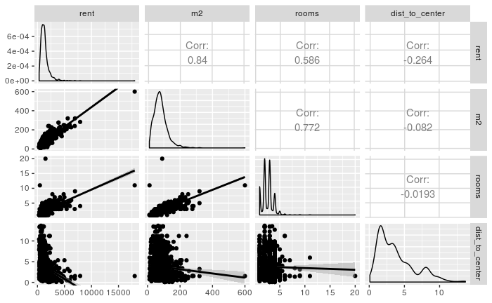

```r
ggpairs(fr_train[, c(2:4,20)], lower = list(continuous = "smooth"))
```

In addition, the `ggmap` package can be used to plot the rent prices in Frankfurt on a map (this requires an API key; see https://github.com/dkahle/ggmap).

[figure not shown]

```r
# register_google(key = "your key")
map <- qmap("Frankfurt, Germany", zoom = 12, maptype = "hybrid")
map +
  geom_point(data = fr_train, aes(x = lon, y = lat, color = rent), size = 2, alpha = 0.5) +
  scale_color_gradientn(colours = rev(heat.colors(10)))
```

## Grow and prune tree

Our task is to predict rent using $m^2$, rooms, location and distance to city center as features. In order to grow a regression tree, `rpart` is used here, which follows the CART idea.

```r
set.seed(6342)
f_tree <- rpart(rent ~ m2 + rooms + lon + lat + dist_to_center,
                data = fr_train,
                cp = 0.002)
f_tree
```

```
n=1806 (4 observations deleted due to missingness)

node), split, n, deviance, yval
      * denotes terminal node

 1) root 1806 1330212000 1327.3110
   2) m2< 143.5 1688  431169500 1186.6990
     4) m2< 80.9 1051  119724100  941.4971
       8) m2< 55.325 516   49977790  795.8421
        16) dist_to_center>=2.677658 284   18327530  714.4878 *
        17) dist_to_center< 2.677658 232   27469630  895.4310
          34) lon>=8.679183 152   12893670  791.1495 *
          35) lon< 8.679183 80    9782421 1093.5660 *
       9) m2>=55.325 535   48240820 1081.9790
        18) dist_to_center>=3.525649 248   12260430  966.6149 *
        19) dist_to_center< 3.525649 287   29827670 1181.6670 *
     5) m2>=80.9 637  143995700 1591.2640
      10) m2< 107.5 412   47484810 1412.3830
        20) dist_to_center>=3.867014 176   10897300 1242.8750 *
        21) dist_to_center< 3.867014 236   27759240 1538.7950 *
      11) m2>=107.5 225   59187290 1918.8150
        22) dist_to_center>=3.629854 71    5444338 1497.4100 *
        23) dist_to_center< 3.629854 154   35321680 2113.0990
          46) dist_to_center>=0.6679294 143   27045530 2071.7990 *
          47) dist_to_center< 0.6679294 11    4861350 2650.0000 *
   3) m2>=143.5 118  388244500 3338.7690
     6) m2< 252.56 111  119398000 3079.0520
      12) m2< 181.5 72   33329520 2674.9960
        24) dist_to_center>=3.494347 20    3182246 2070.3370 *
        25) dist_to_center< 3.494347 52   20022610 2907.5580
          50) lon>=8.683437 10    1009522 2419.5000 *
          51) lon< 8.683437 42   16063940 3023.7620 *
      13) m2>=181.5 39   52612600 3825.0000
        26) dist_to_center>=1.360823 29   19663270 3510.5170 *
        27) dist_to_center< 1.360823 10   21763810 4737.0000 *
     7) m2>=252.56 7  142632100 7457.1430 *
```

Given the grown tree, `printcp()` and `plotcp()` help us to determine the best subtree, whereas `Root node error` times `xerror` gives us the estimated test error for each subtree based on cross-validation.

```r
printcp(f_tree)
```

```
Regression tree:
rpart(formula = rent ~ m2 + rooms + lon + lat + dist_to_center,
    data = fr_train, cp = 0.002)

Variables actually used in tree construction:
[1] dist_to_center lon            m2

Root node error: 1330212156/1806 = 736552

n=1806 (4 observations deleted due to missingness)

          CP nsplit rel error  xerror    xstd
1  0.3839975      0   1.00000 1.00190 0.21989
2  0.1258820      1   0.61600 0.64794 0.17925
3  0.0948828      2   0.49012 0.59674 0.18004
4  0.0280583      3   0.39524 0.48600 0.15025
5  0.0251508      4   0.36718 0.46630 0.15005
6  0.0161670      5   0.34203 0.44476 0.14993
7  0.0138484      6   0.32586 0.43399 0.14992
8  0.0084088      7   0.31201 0.39770 0.13221
9  0.0076113      8   0.30360 0.38682 0.13219
10 0.0066367      9   0.29599 0.37997 0.13217
11 0.0046254     10   0.28936 0.37123 0.13202
12 0.0033732     11   0.28473 0.36859 0.13202
13 0.0025671     13   0.27798 0.36081 0.13192
14 0.0022170     14   0.27542 0.36017 0.13192
15 0.0020000     15   0.27320 0.35740 0.13192
```

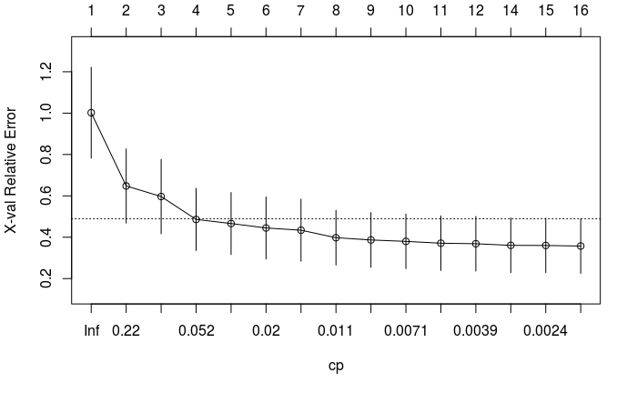

```r
plotcp(f_tree)
```

On this basis, we are interested in picking the cp value that is associated with the smallest CV error. We could do this by hand or by using a few lines of code.

```r
minx <- which.min(f_tree$cptable[,"xerror"])
mincp <- f_tree$cptable[minx,"CP"]
mincp
```

```
[1] 0.002
```

Alternatively, we could also pick the best subtree based on the 1-SE rule. We are again interested in storing the corresponding cp value for tree pruning in the next step.

```r
minx <- which.min(f_tree$cptable[,"xerror"])
minxse <- f_tree$cptable[minx,"xerror"] + f_tree$cptable[minx,"xstd"]
minse <- which(f_tree$cptable[1:minx,"xerror"] < minxse)
mincp2 <- f_tree$cptable[minse[1],"CP"]
mincp2
```

```
[1] 0.02805835
```

Now we can get the best subtree with the prune function. First based on the smallest CV error…

```r
p_tree <- prune(f_tree, cp = mincp)
p_tree
```

```
n=1806 (4 observations deleted due to missingness)

node), split, n, deviance, yval
      * denotes terminal node

 1) root 1806 1330212000 1327.3110
   2) m2< 143.5 1688  431169500 1186.6990
     4) m2< 80.9 1051  119724100  941.4971
       8) m2< 55.325 516   49977790  795.8421
        16) dist_to_center>=2.677658 284   18327530  714.4878 *
        17) dist_to_center< 2.677658 232   27469630  895.4310
          34) lon>=8.679183 152   12893670  791.1495 *
          35) lon< 8.679183 80    9782421 1093.5660 *
       9) m2>=55.325 535   48240820 1081.9790
        18) dist_to_center>=3.525649 248   12260430  966.6149 *
        19) dist_to_center< 3.525649 287   29827670 1181.6670 *
     5) m2>=80.9 637  143995700 1591.2640
      10) m2< 107.5 412   47484810 1412.3830
        20) dist_to_center>=3.867014 176   10897300 1242.8750 *
        21) dist_to_center< 3.867014 236   27759240 1538.7950 *
      11) m2>=107.5 225   59187290 1918.8150
        22) dist_to_center>=3.629854 71    5444338 1497.4100 *
        23) dist_to_center< 3.629854 154   35321680 2113.0990
          46) dist_to_center>=0.6679294 143   27045530 2071.7990 *
          47) dist_to_center< 0.6679294 11    4861350 2650.0000 *
   3) m2>=143.5 118  388244500 3338.7690
     6) m2< 252.56 111  119398000 3079.0520
      12) m2< 181.5 72   33329520 2674.9960
        24) dist_to_center>=3.494347 20    3182246 2070.3370 *
        25) dist_to_center< 3.494347 52   20022610 2907.5580
          50) lon>=8.683437 10    1009522 2419.5000 *
          51) lon< 8.683437 42   16063940 3023.7620 *
      13) m2>=181.5 39   52612600 3825.0000
        26) dist_to_center>=1.360823 29   19663270 3510.5170 *
        27) dist_to_center< 1.360823 10   21763810 4737.0000 *
     7) m2>=252.56 7  142632100 7457.1430 *
```

…and now based on the 1-SE rule.

```r
p_tree2 <- prune(f_tree, cp = mincp2)
p_tree2
```

```
n=1806 (4 observations deleted due to missingness)

node), split, n, deviance, yval
      * denotes terminal node

1) root 1806 1330212000 1327.3110
  2) m2< 143.5 1688  431169500 1186.6990
    4) m2< 80.9 1051  119724100  941.4971 *
    5) m2>=80.9 637  143995700 1591.2640 *
  3) m2>=143.5 118  388244500 3338.7690
    6) m2< 252.56 111  119398000 3079.0520 *
    7) m2>=252.56 7  142632100 7457.1430 *
```

## Plots

An advantage of trees is that they can be easily interpreted by a simple plot. The `party` package produces nice tree plots.

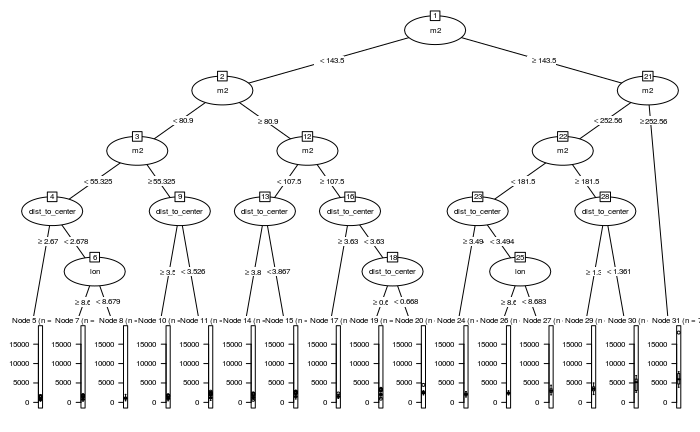

```r
prty_tree <- as.party(p_tree)
plot(prty_tree, gp = gpar(fontsize = 6))
```

Here we plot the smaller tree, which was pruned based on the 1SE rule.

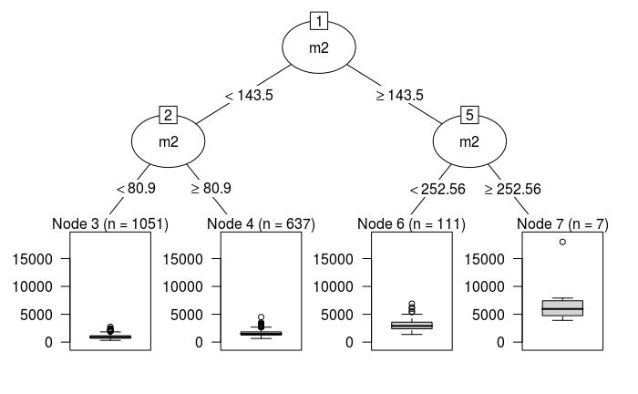

```r
prty_tree2 <- as.party(p_tree2)
plot(prty_tree2)
```

If we are interested in the prediction surface of a tree, partial dependence plots using e.g. the `pdp` package can be useful.

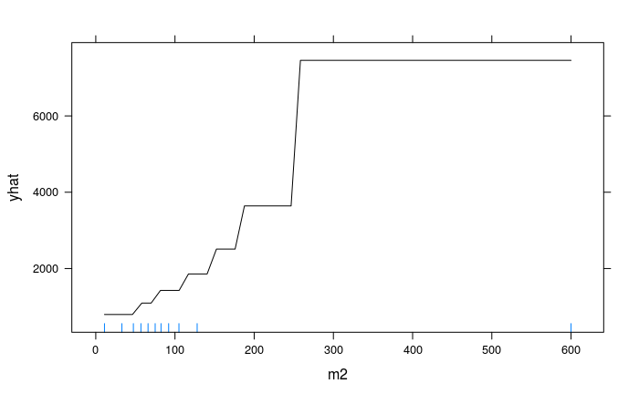

```r
pdp1 <- partial(p_tree, pred.var = "m2")
plotPartial(pdp1, rug = T, train = fr_train, alpha = 0.3)
```

The `pdp` package also allows to plot prediction surfaces based on two predictors.

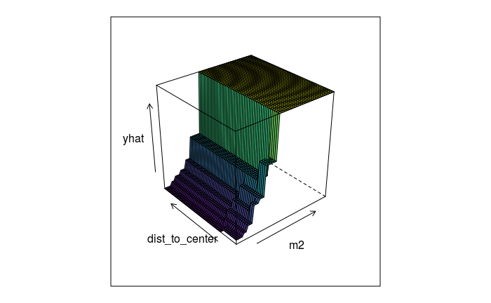

```r
pdp2 <- partial(p_tree, pred.var = c("m2", "dist_to_center"))
plotPartial(pdp2, levelplot = F, drape = T, colorkey = F, screen = list(z = 40, x = -60))
```

## Prediction

Finally, we can use the pruned trees in order to predict the outcome in the holdout (test) set.

```r
y_tree <- predict(p_tree, newdata = fr_test)
y_tree2 <- predict(p_tree2, newdata = fr_test)
```

`RMSE()` and `R2()` can be used to produce basic performance measures.

```r
RMSE(pred = y_tree, obs = fr_test$rent, na.rm = TRUE)
```

```
[1] 586.4978
```

```r
R2(pred = y_tree, obs = fr_test$rent, na.rm = TRUE)
```

```
[1] 0.7157974
```

```r
RMSE(pred = y_tree2, obs = fr_test$rent, na.rm = TRUE)
```

```
[1] 678.2995
```

```r
R2(pred = y_tree2, obs = fr_test$rent, na.rm = TRUE)
```

```
[1] 0.6180164
```

## References

- https://cran.r-project.org/web/packages/rpart/vignettes/longintro.pdf